# Week 14：高维问题、共线性与降维回归

**主题**：`PCA` / `PCR`

**本节课主线**：

- 为什么 `p > n` 和共线性会一起把 `OLS` 逼到危险地带？
- `PCA` 到底在压缩什么？
- `PCR` 为什么能在高维相关数据里稳住回归？
- `Lasso` 和 `PCR` 分别更适合什么世界？

**课堂规则**：

- 先猜，再运行；
- 先看现象，再命名；
- 先做判断，再背术语。

## Prologue：今天我们不再只问“谁该留下”，而要问“信息该怎么压缩”

上周我们在原变量空间里讨论了 `Ridge`、`Lasso`、`Elastic Net`。 它们都在回答一个问题：

> 当 `OLS` 不够稳时，我们怎么在原变量空间里加约束？

但现实里还有另一种很常见的情况：

- 变量很多；
- 变量彼此相关；
- 我们掌握的信息，不足以对每一列都做出稳定而准确的估计。

这背后的原因通常有两类：

- 要么是 `p > n`，每一列平均分到的信息太少；
- 要么是共线性太强，几列变量在争夺同一份解释权。

这时，问题不一定是“删掉谁”，也可能是：

> 要不要先换一个更紧凑的坐标系，再做回归？

## 第一幕：维度一高，`OLS` 还能不能信？

这一幕先不急着谈 `PCA`。 先回答更基础的问题：

> 当特征数不断上升，尤其开始逼近甚至超过训练样本数时，`OLS` 会发生什么？

先猜一个趋势：

如果我们固定样本量，只让特征数 `p` 越来越大，你觉得哪件事更可能发生？

1. 训练误差和测试误差都会稳定下降；
2. 训练误差会越来越漂亮，但泛化未必跟着更好。

先看一个极端例子：

- 一元回归里，如果训练集只有 `n = 1` 个点；
- 我们总能找到一条直线，把这个点“拟合得完美无缺”；
- 于是训练误差一定是 0。

但这并不说明模型学到了规律。 它只说明：**约束太少时，模型可以轻易把训练集讲圆。**

**本幕主图**：随着 `p` 上升，`OLS` 的 train/test 误差与矩阵秩变化

这张图要回答：

> `OLS` 的危险到底是“算不出来”，还是“太容易给出一个看起来很完美的答案”？

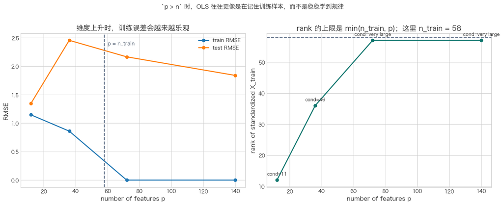

|  | p | n_train | p_over_n_train | rank(X_train) | train_rmse | test_rmse | condition_number |
| --- | --- | --- | --- | --- | --- | --- | --- |
| 0 | 12 | 58 | 0.21 | 12 | 1.146647e+00 | 1.347267 | 11 |
| 1 | 36 | 58 | 0.62 | 36 | 8.601513e-01 | 2.455842 | 46 |
| 2 | 72 | 58 | 1.24 | 57 | 7.055216e-15 | 2.165933 | very large |
| 3 | 140 | 58 | 2.41 | 57 | 9.478850e-15 | 1.839490 | very large |

这里，大家需要记住的是：

- `p > n` 时，`OLS` 不一定报错，但自由度会非常大；
- 训练误差接近 0，不代表模型已经“学得很好”；
- 问题的核心不是能不能拟合，而是拟合是否稳定、是否可泛化。

**这里顺手补两个词**

- `condition number`：最大奇异值与最小奇异值之比 $$ \kappa(X) = \frac{\sigma_{\max}(X)}{\sigma_{\min}(X)} $$ 它越大，说明设计矩阵越接近“某些方向上快要塌掉”。
- `自由度`：这里可以先直观理解成“模型可以独立摆动的方向数”。

当 `p` 上升、而样本量没跟上时，可摆动的方向越来越多，但每个方向获得的证据越来越少。

**把直观和严格定义对应起来**

这里看到的风险，可以用 $OLS$ 的标准写法来表达：

$$ \hat{\beta}_{OLS} = (X^\top X)^{-1} X^\top y $$

当 $p$ 逼近甚至超过 $n$ 时，$X^\top X$ 更容易：

- 不可逆；
- 或者虽然可逆，但病态得非常严重。

同时还要记住一个简单关系：

- $rank(X^\top X) = rank(X)$；
- 所以一旦 $rank(X) < p$，$X^\top X$ 就不可能满秩。

这时图里看到的“训练误差很低、但模型不稳”，就对应着： 系数解不唯一，或者对样本扰动极度敏感。

## 第二幕：共线性为什么会破坏解释？

上一幕强调的是“变量太多”。 这一幕强调的是“信息太重复”。

> 就算 `p` 还没有超过 `n`，只要变量彼此强相关，`OLS` 也会开始摇摆。

如果三个变量几乎都在描述同一件事，你觉得 `OLS` 更可能：

1. 很稳定地把功劳分给它们；
2. 在不同样本切分下，反复改变谁来“扛主力”。

回忆一下上周的 `Ridge`：

- 它不是把某一列直接删掉；
- 而是通过 `L2 penalty` 让几列相关变量更倾向于**平滑地共享功劳**；
- 所以在“谁该留下”之外，`Ridge` 更关心“怎样让估计更稳定”。

这一幕可以把 `OLS` 和 `Ridge` 的气质先区分开： `OLS` 更容易在相关变量之间剧烈摇摆，`Ridge` 更愿意保守地平均分担。

**本幕主图**：弱相关 vs 强相关 场景下，`OLS` 系数跨切分波动对比

这张图要回答：

> 共线性破坏的，到底是误差、系数，还是解释本身？

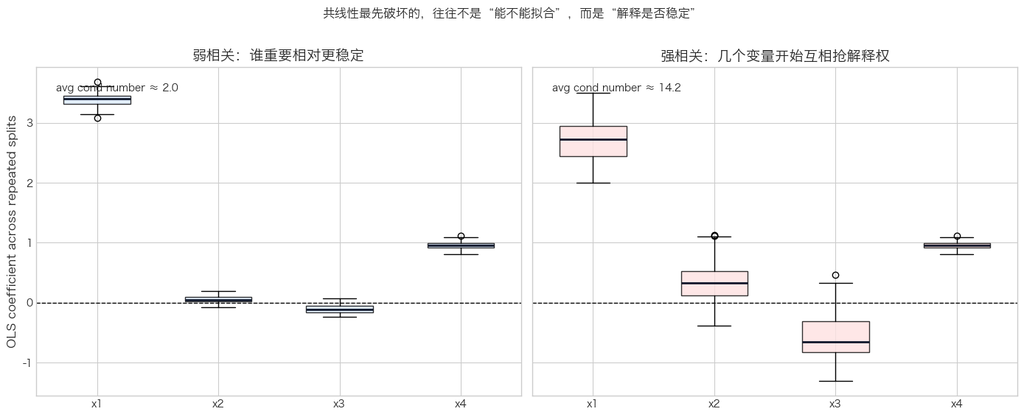

这里，大家需要理解的是：

- 多重共线性会放大系数方差，让“谁更重要”这件事变得摇摆；
- 高维和共线性不是同一个原因，但它们常常同时出现，并共同削弱原变量空间里的稳定估计。

**把直观和严格定义对应起来**

如果仍然写成

$$ \hat{\beta}_{OLS} = (X^\top X)^{-1} X^\top y $$

那么强共线性对应的是：

- $X$ 的列彼此接近线性相关；
- $X^\top X$ 虽然可能可逆，但条件数会很大；
- 因而 $\hat{\beta}$ 对样本切分和噪声非常敏感。

所以图里看到的“几个变量互相抢解释权”，本质上就是矩阵病态带来的系数不稳定。

## 第三幕：`PCA` 在压缩什么？

既然原变量空间里充满重复信息，一个自然问题就是：

> 我们能不能先换个坐标系，让主要信息沿着更少的方向表达？

看二维图之前先猜：

如果一团点呈现出明显的“斜着拉长”的椭圆形，你觉得最值得保留的方向会是：

1. 沿着最长扩散方向；
2. 沿着最窄、最安静的方向。

**本幕主图**：二维相关数据 + 主成分方向

这张图要回答：

> 主成分不是在挑变量，而是在找“变化最大的信息方向”。

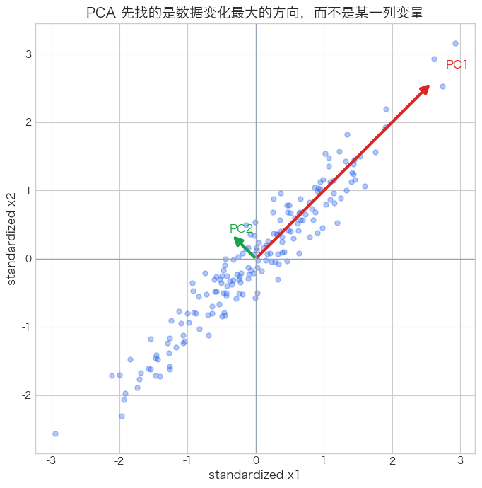

$PCA$ 的一个关键词是：

$projection$

它做的不是“删掉某一列”，而是把原始变量投影到一组新的正交方向上。

**先把算法步骤说清楚**

一个最朴素的 `PCA` 过程可以写成：

1. 先标准化各列变量；
2. 计算协方差结构；
3. 找到投影方差最大的方向作为 `PC1`；
4. 在与 `PC1` 正交的约束下，继续找 `PC2`、`PC3`；
5. 用前几个主成分来近似原来的高维数据。

所以 `PCA` 不是“随便取平均”，而是在系统地寻找最能保留变化的方向。

**本幕辅图**：高维低秩数据中的累计解释方差

这张图要把二维直觉迁移到高维：

> 如果前几个主成分已经解释了大部分方差，就说明原数据虽然住在高维空间里，但主要变化其实贴近一个更低维的平面或子空间。

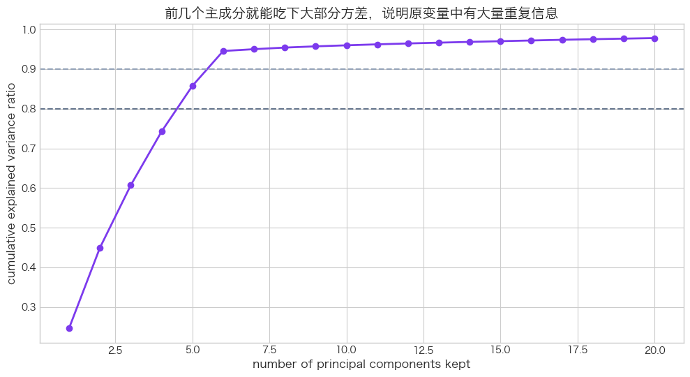

这里，大家需要记住的是：

- `PCA` 解决的是“如何用更少的方向保留主要信息”；
- 它优先保留的是 `X` 中方差大的方向；
- 所以 `PCA` 还不是回归，它只是为后面的 `PCR` 准备了一个低维表示。

**把直观和严格定义对应起来**

在严格定义里，第一主成分方向 $v_1$ 满足：

$$ v_1 = \arg\max_{\|v\|=1} \mathrm{Var}(Xv) $$

后续主成分继续满足：

- 仍然最大化投影方差；
- 彼此正交。

所以刚才图里的“最长扩散方向”，在数学上就是： 在所有单位方向里，投影方差最大的那个方向。

## 第四幕：`PCR` 到底做了什么？

有了 `PCA` 之后，一个自然流程就是：

1. 先标准化；
2. 做 `PCA`；
3. 保留前 `k` 个主成分；
4. 在这些主成分上做线性回归。

这就是 `PCR`。

先猜：

如果 $PCR$ 里的主成分个数 $k$ 从 1 一直加到很多，你觉得测试误差更可能：

1. 单调下降；
2. 先下降，后面可能又把噪声带回来。

**本幕主图**：`PCR` 随主成分个数变化的 train/test/CV 误差曲线

这张图要回答：

> `PCR` 的关键调参对象不是“留哪个变量”，而是“保留多少个方向”。

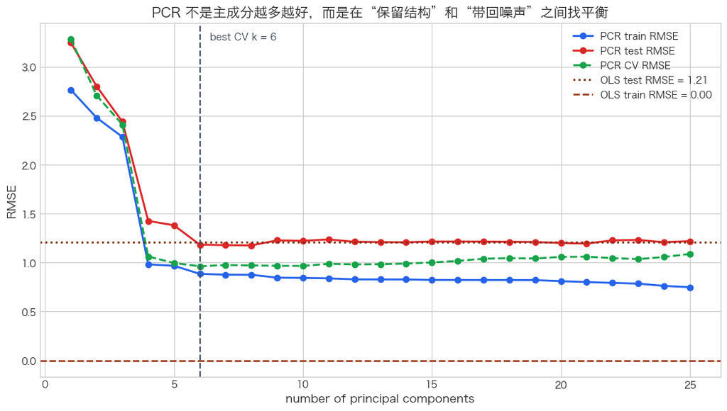

这张图最值得课堂上反复强调的，是这三点：

- `OLS` 在原始高维空间里可以把训练误差压得很低；
- `PCR` 用少量主成分就能抓住主要结构，测试误差反而更稳；
- 成分太多时，后面的方向也会把噪声重新带回来。

**怎么读 `PCR CV RMSE` 这条线？**

- 它是交叉验证下的平均测试误差，用来估计“如果换一批新样本，模型大概会表现怎样”；
- 它不像 train RMSE 那样容易被“贴着训练集讲故事”迷惑；
- 它和 test RMSE 的趋势接近，说明 `PCR` 的优劣主要确实取决于保留多少个主成分。

这张图里 `OLS` 的 train error 很低，甚至接近 0，并不是因为它更聪明， 而是因为原始高维空间给了它过多自由度。 `CV` 在这里的主要作用，就是帮我们选择更合适的主成分个数 `k`。

这里，大家需要记住的是：

$PCR$ 的本质不是变量筛选，而是：

> 先做 `information compression`，再回归。

**把直观和严格定义对应起来**

$PCR$ 的流程可以写成：

1. 先把标准化后的 $X$ 投影到前 $k$ 个主成分上，得到 $$ Z_k = X V_k $$
2. 再做线性回归： $$ y = Z_k \gamma + \varepsilon $$

也就是说，$PCR$ 并不是在原变量 $X_1, \ldots, X_p$ 上直接筛选， 而是在低维表示 $Z_k$ 上回归。

所以图里“成分个数 `k` 的选择”，在数学上对应的正是： 要保留多少个主成分方向进入回归。

## 第五幕：`Lasso` vs `PCR`，你到底想解决哪一种问题？

到这里，终于可以把这周和上周接起来了。

真正要问的不是“谁更高级”，而是：

> 数据的真实结构更像“少数原始变量直接有效”，还是“原始变量主要是由少数潜在因子的线性组合生成出来的”？

先做一个方法下注：

如果真实世界是“只有少数原始变量直接有用”，你更偏向 `Lasso` 还是 `PCR`？

如果真实世界是“很多变量一起表达几个潜在因子”，你又会偏向谁？

**本幕主图**：两种数据世界里，`Lasso` 与 `PCR` 的表现对比

我们直接造两个世界：

1. `Sparse truth`：只有少数原始变量真正有用；
2. `Latent-factor truth`：原始变量主要由少数潜在因子线性组合生成。

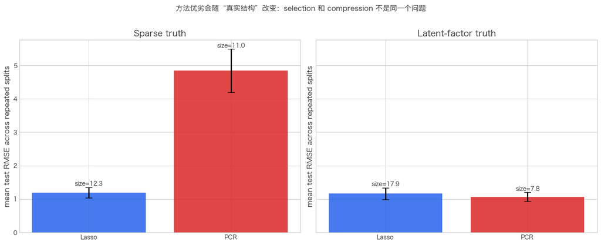

|  | scenario | method | mean_test_rmse | sd_test_rmse | avg_model_size | coef_instability |
| --- | --- | --- | --- | --- | --- | --- |
| 0 | Latent-factor truth | Lasso | 1.164 | 0.178 | 17.9 | 0.077 |
| 1 | Latent-factor truth | PCR | 1.070 | 0.131 | 7.8 | 0.060 |
| 2 | Sparse truth | Lasso | 1.192 | 0.159 | 12.3 | 0.018 |
| 3 | Sparse truth | PCR | 4.845 | 0.643 | 11.0 | 0.183 |

这张表里最值得读的，不只是预测误差，还有两个维度：

- `avg_model_size`
  - 对 `Lasso`，它表示平均留下了多少个非零系数；
  - 对 `PCR`，它表示平均保留了多少个主成分。
- `coef_instability`
  - 它这里定义为：先对每个系数看“跨切分的标准差”，再对所有系数取平均；
  - 数值越大，说明同一方法在不同切分下给出的系数更容易波动。

这里，大家需要记住的是：

- `Lasso` 更适合回答：**谁留下？**
- `PCR` 更适合回答：**先把重复信息压缩掉，再预测会不会更稳？**

对应到真实场景：

- 基因表达、文本词项、传感器阵列：往往更容易出现高维和强相关；
- 如果你更需要短名单，`Lasso` 更自然；
- 如果你更需要把成团的信息压缩成稳定表征，`PCR` 往往更顺手。

## Synthesis

今天的整节课，其实都在回答同一个问题：

> 当原变量空间已经拥挤、重复、摇摆时，我们该在原空间里筛选，还是先换坐标、再回归？

到这里，大家需要记住 5 个判断：

1. `p > n` 会让 `OLS` 更容易把训练集讲圆，却更难保证泛化；
2. 共线性会让系数解释摇摆，哪怕预测误差还没立刻爆炸；
3. `PCA` 做的是坐标变换与信息压缩；
4. `PCR` 做的是先压缩、再回归，不是直接给变量名单；
5. `Lasso` 和 `PCR` 的差异，本质上是 `selection` vs `compression`。

## Transition

今天我们一直在默认：先把 `y` 当作旁观者，只根据 `X` 的结构来整理特征空间。

但一个自然问题是：

> 如果某个方差很大的方向，其实和 `y` 没那么相关，怎么办？

这就把我们带向下一个更大的主题：

> 当响应变量不再只是连续数值，而是类别标签时，我们该怎样直接建模 $P(y \mid X)$？

这会把我们带到下一周：`广义线性模型（GLM）核心：逻辑回归`。